# Mid project

2024-02-18

**Dataset Information**

Country: Name of the country

Region: continent of the country

Child_mort: child mortality under 5 years old per 1000 live births.

Health: total health spending per capita.

Exports: exports of goods per capita.

Imports: imports of goods per capita.

Income: net income per person.

Inflation: the measurement of the annual growth rate of the total GDP.

Life_expec: the average of years that a born child would live in a country with the same parameters.

Total_fer: the number of childr that would born to each woman.

Gdpp: GDP per capita.

Libraries

```r
library(tidyverse)
```

```r
library(leaflet)
library(mapboxapi)
library(sf)
library(readxl)
library(stringr)
library(mice)
library(cluster)
library(mclust)
library(factoextra)
library(RColorBrewer)
```

Pre-process data and descriptive analysis

First, we have to download the csv country and region, and this last dataset we transform the column name into country to make a left join.

```r
country <- read.csv("Country-data.csv")
```

```r
region <- read.csv("all.csv")

region <- region |>
  rename(country = name)
```

We do the left join and then, we use mutate, if_else to put the NAs of the regions that neither of the dataset datected.

```r
result <- left_join(country, region, by = "country")

result <- result |>
  mutate(region = if_else(country%in%c("Bolivia", "United States", "Venezuela", "St. Vincent and the Grenadines"), "Americas", region)) |>
  mutate(region = if_else(country%in%c("Moldova", "Russia", "Slovak Republic", "United Kingdom", "Macedonia", "Czech Republic"), "Europe", region)) |>
  mutate(region = if_else(country%in%c("Rep Dem Congo", " Rep Congo", "Cape Verde", "Cote d'Ivoire", "Tanzania"), "Africa", region)) |>  mutate(region = if_else(country%in%c("Vietnam", "South Korea", "Lao", "Iran", "Kyrgyz Republic", "Brunei"), "Asia", region)) |>
  mutate(region = if_else(country%in%c("Micronesia. Fed. Sts."), "Oceania", region))
```

Finally, we check if we have only 5 regions.

```r
x <- result |>
  pull(region) |>
  unique()
```

And we have the summary of our dataset

```r
summary(result)
```

```
##    country            child_mort        exports            health
##  Length:167         Min.   :  2.60   Min.   :  0.109   Min.   : 1.810
##  Class :character   1st Qu.:  8.25   1st Qu.: 23.800   1st Qu.: 4.920
##  Mode  :character   Median : 19.30   Median : 35.000   Median : 6.320
##                     Mean   : 38.27   Mean   : 41.109   Mean   : 6.816
##                     3rd Qu.: 62.10   3rd Qu.: 51.350   3rd Qu.: 8.600
##                     Max.   :208.00   Max.   :200.000   Max.   :17.900
##
##     imports             income         inflation         life_expec
##  Min.   :  0.0659   Min.   :   609   Min.   : -4.210   Min.   :32.10
##  1st Qu.: 30.2000   1st Qu.:  3355   1st Qu.:  1.810   1st Qu.:65.30
##  Median : 43.3000   Median :  9960   Median :  5.390   Median :73.10
##  Mean   : 46.8902   Mean   : 17145   Mean   :  7.782   Mean   :70.56
##  3rd Qu.: 58.7500   3rd Qu.: 22800   3rd Qu.: 10.750   3rd Qu.:76.80
##  Max.   :174.0000   Max.   :125000   Max.   :104.000   Max.   :82.80
##
##    total_fer          gdpp          alpha.2            alpha.3
##  Min.   :1.150   Min.   :   231   Length:167         Length:167
##  1st Qu.:1.795   1st Qu.:  1330   Class :character   Class :character
##  Median :2.410   Median :  4660   Mode  :character   Mode  :character
##  Mean   :2.948   Mean   : 12964
##  3rd Qu.:3.880   3rd Qu.: 14050
##  Max.   :7.490   Max.   :105000
##
##   country.code    iso_3166.2           region           sub.region
##  Min.   :  4.0   Length:167         Length:167         Length:167
##  1st Qu.:191.0   Class :character   Class :character   Class :character
##  Median :400.0   Mode  :character   Mode  :character   Mode  :character
##  Mean   :406.7
##  3rd Qu.:616.0
##  Max.   :894.0
##  NA's   :22
##  intermediate.region  region.code     sub.region.code intermediate.region.code
##  Length:167          Min.   :  2.00   Min.   : 15.0   Min.   : 5.00
##  Class :character    1st Qu.:  2.00   1st Qu.: 39.0   1st Qu.:11.00
##  Mode  :character    Median : 19.00   Median :154.0   Median :13.50
##                      Mean   : 76.42   Mean   :168.2   Mean   :14.03
##                      3rd Qu.:142.00   3rd Qu.:202.0   3rd Qu.:17.00
##                      Max.   :150.00   Max.   :419.0   Max.   :29.00
##                      NA's   :22       NA's   :22      NA's   :109
```

In order to visualize the date, I want to get to know which region has more GDP.

```r
mean_child_mort <- result |>
  group_by(region) |>
  summarize(mean_child_death = mean(child_mort, na.rm = TRUE)) |>
  ggplot(aes(x = region, y = mean_child_death, fill = region)) +
  geom_bar(stat = "identity") +
  theme_classic() +
  labs(title = "Mean of Child Mortality by region", x = "Region", y = "Mean Child Mortality")
```

Eurpe is the continent with more GDP, followed by Asia and America.

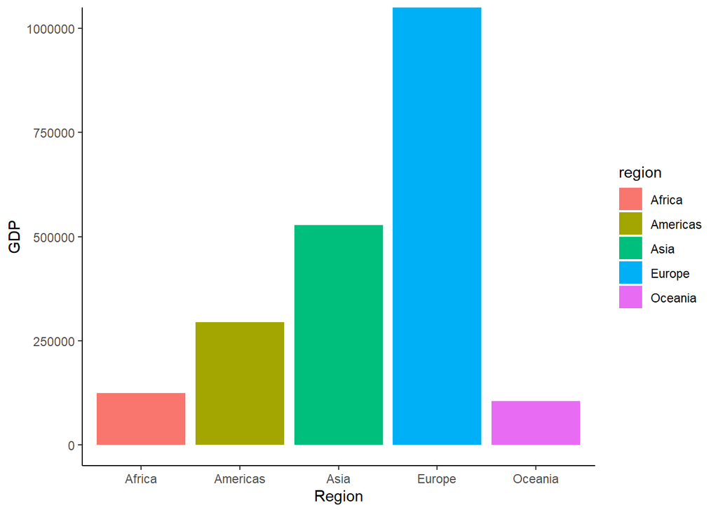

```r
r <- result |>
  ggplot() +
  aes(x = region, y = gdpp, fill = region) +
  geom_bar(stat = "identity") +
  theme_classic() +
  labs(x = "Region", y = "GDP") +
  coord_cartesian(ylim = c(0, 1000000))
r
```

After this, we have a geom point to compare GDP and Fertility Rate. If we look carefully to the points, we see that a lower fertility rate is correlated with a high GDP. Most of the red points(Africa) have a high level of fertility and a low GDP.

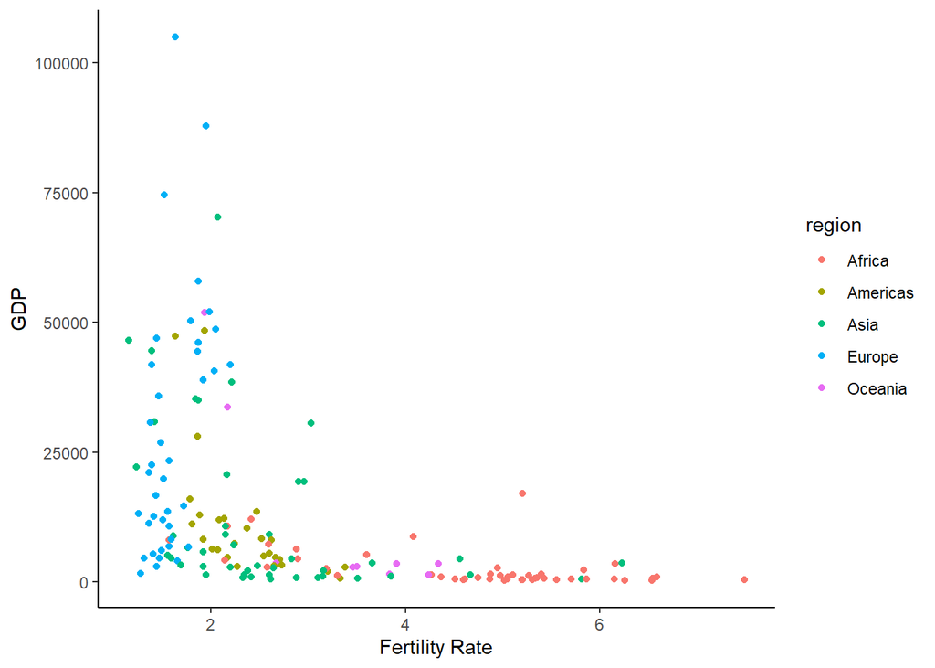

```r
s <- result |>
  ggplot() +
  aes(x = total_fer, y = gdpp, color = region) +
  geom_point() +
  theme_classic() +
  labs(x = "Fertility Rate", y = "GDP")
s
```

We have similar result with life expectancy and total fertility. Hence, if a country has high GDP and Life expectancy, it will probably has a low fertility rate.

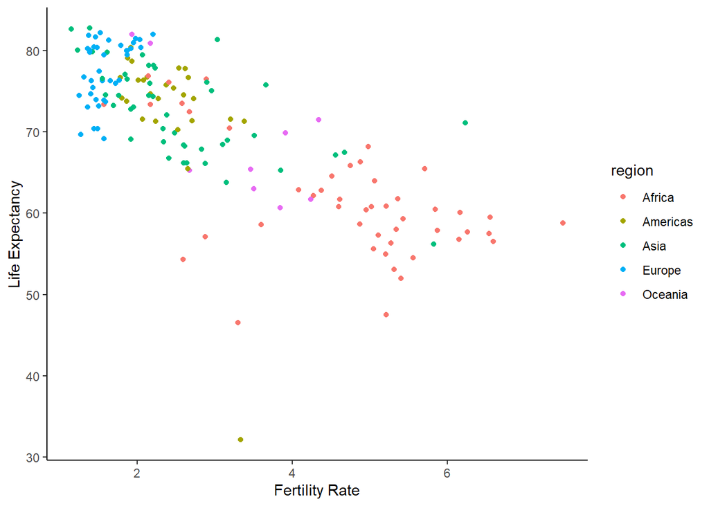

```r
w <- result |>
  ggplot() +
  aes(x = total_fer, y = life_expec, color = region) +
  geom_point() +
  theme_classic() +
  labs(x = "Fertility Rate", y = "Life Expectancy")
w
```

Child mortality and life expectancy are correlated as well. Developed countries usually tent to be at the left corner of this plot. Therefore, our conclusion is that a higher mortality rate, it affects drammatically our life expectancy.

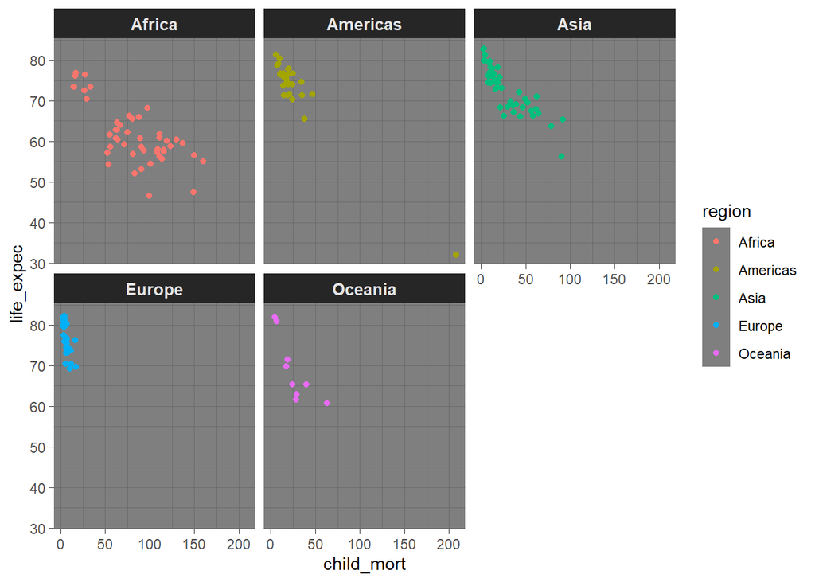

```r
a <- result |>
  ggplot() +
  aes(x = child_mort, y = life_expec, color = region) +
  geom_point() +
  facet_wrap(~region) +
  theme_dark() +
  theme(strip.text = element_text(size = 10, face = "bold"))
a
```

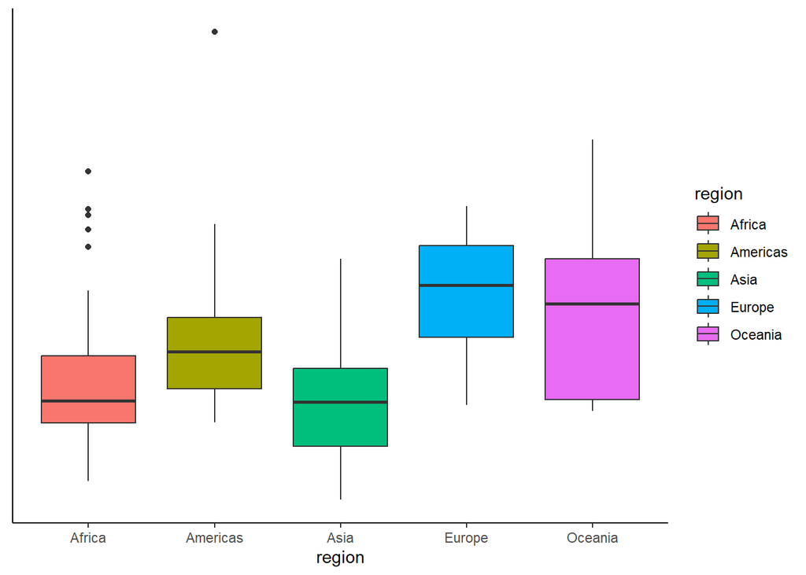

```r
q <-result %>%
  ggplot() +
  aes(x = region, y = health, fill = region) +
  geom_boxplot() +
  theme_classic() +
  theme(axis.title.y = element_blank(), axis.text.y = element_blank(), axis.ticks.y = element_blank())
q
```

**Feature engineering**

For this part we will remove all the columns that do not have a numbers to use in the following techniques.

```r
result_tidy <- result |>
  select(-c(alpha.2,alpha.3,country.code,iso_3166.2,sub.region,intermediate.region,region.code,sub.region.code,intermediate.region.code))
```

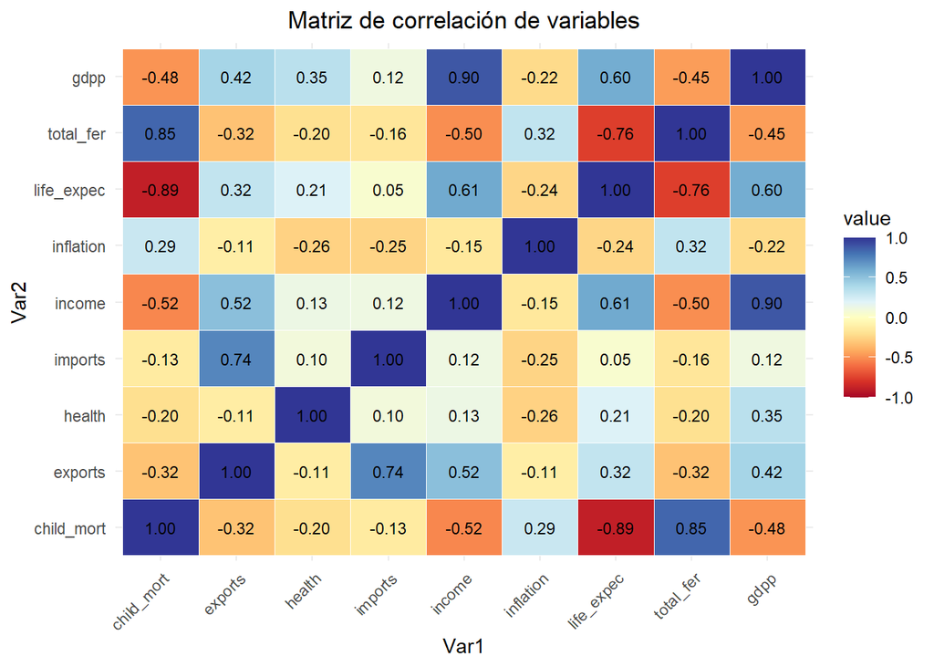

```r
datos_numericos <- result_tidy |>  select(-country, -region)

cor_matrix <- cor(datos_numericos)

cor_df <- reshape2::melt(cor_matrix)



colors <- brewer.pal(n = 11, name = "RdYlBu")

ggplot(cor_df, aes(Var1, Var2, fill = value)) +
  geom_tile(color = "white") +
  geom_text(aes(label = sprintf("%.2f", value)), color = "black", size = 3) +
  scale_fill_gradientn(colors = colors, limits = c(-1, 1), na.value = "white") +
  theme_minimal() +
  labs(title = "Matriz de correlación de variables") +
  theme(axis.text.x = element_text(angle = 45, hjust = 1),
        plot.title = element_text(hjust = 0.5))
```

**PCA**

In this database, we do not have NAs, so we do not need to imput.

```r
sapply(result_tidy, function(x) sum(is.na(x)))
```

```
##    country child_mort    exports     health    imports     income  inflation
##          0          0          0          0          0          0          0
## life_expec  total_fer       gdpp     region
##          0          0          0          0
```

With this code, we obtain the components of the PCA(Principal component analysis). The first component obtain the largest variation of the dataset, the second, the second largest and so on.

```r
pca_result <- result_tidy |>
  select(-c(country, region))

pca_result <- prcomp(pca_result,scale. = TRUE)
summary(pca_result)
```

```
## Importance of components:
##                           PC1    PC2    PC3    PC4    PC5     PC6    PC7
## Standard deviation     2.0336 1.2435 1.0818 0.9974 0.8128 0.47284 0.3368
## Proportion of Variance 0.4595 0.1718 0.1300 0.1105 0.0734 0.02484 0.0126
## Cumulative Proportion  0.4595 0.6313 0.7614 0.8719 0.9453 0.97015 0.9828
##                            PC8     PC9
## Standard deviation     0.29718 0.25860
## Proportion of Variance 0.00981 0.00743
## Cumulative Proportion  0.99257 1.00000
```

When we plot it, with just 3 components we obtain more than 75% of variability.

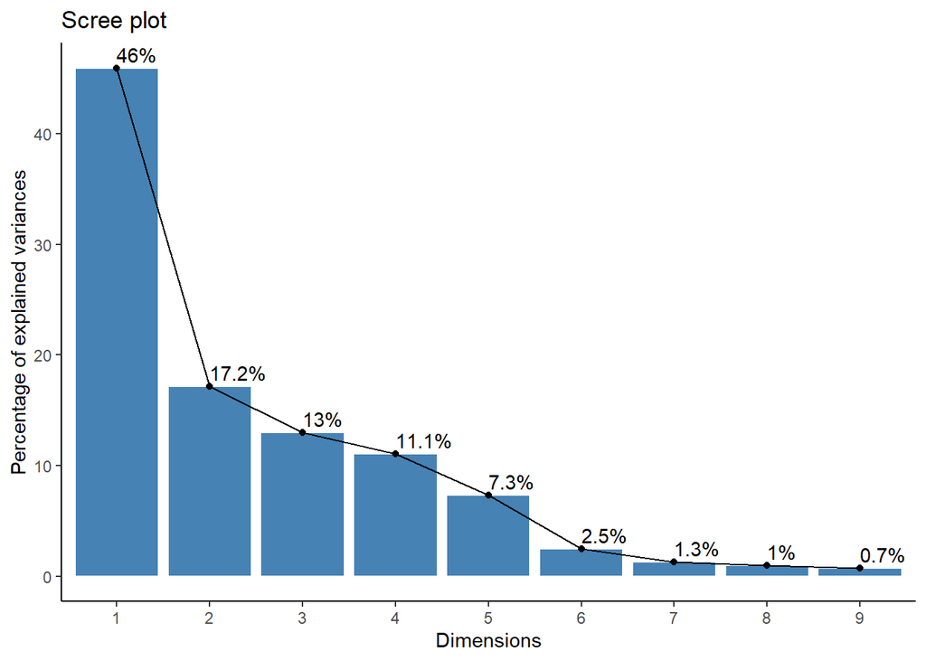

```r
fviz_screeplot(pca_result,addlabels = TRUE, barcolor = "white") +
  theme_classic()
```

Plotting it, we can visualiza that child mortality, life expectancy, total fertility, and income/gdp(those are quite similar) are the most importants components.

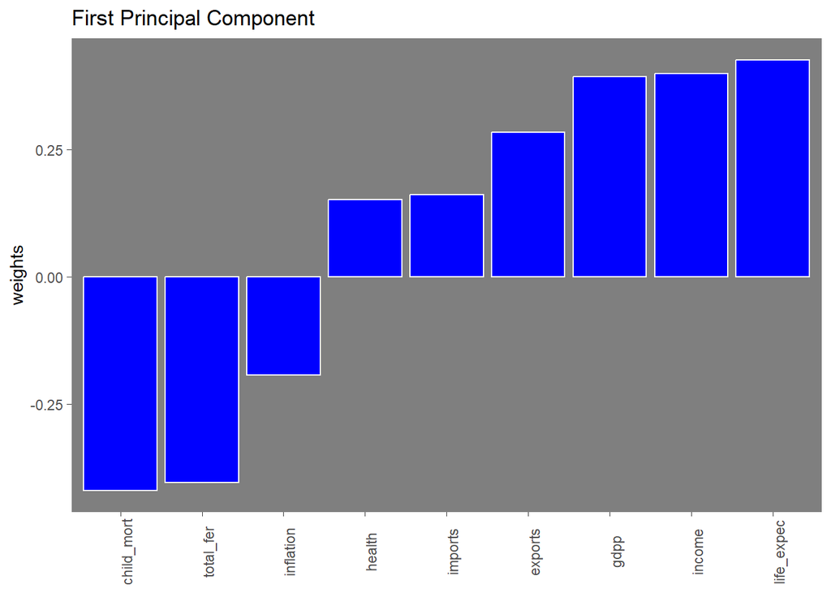

```r
first_component_result <- pca_result$rotation[,1] |>
  as.data.frame() |>
  rename(weights = 1)

names <- rownames(first_component_result)
first_component_result <- cbind(names,first_component_result)

pca_plot <- first_component_result |>
  ggplot()+
  aes(reorder(names,weights),weights)+
  geom_bar(stat = "identity", color = "white", fill = "blue")+
  theme_dark()+
  theme(panel.grid = element_blank(),
        axis.text.x = element_text(angle = 90),
        axis.title.x = element_blank())+
  labs(title = "First Principal Component")

pca_plot
```

The red line that we obtain means that the expected average contribution of the components.

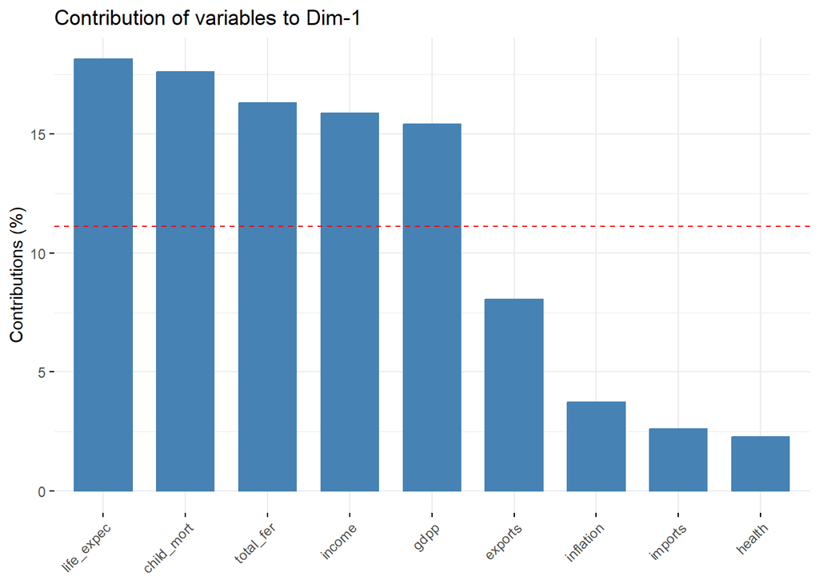

```r
fviz_contrib(pca_result, choice = "var", axes = 1)
```

According to the first component, all these countries are the best when we rank them.

```r
names <- result_tidy|>
  pull(country)
Continent <-  result_tidy |>
  pull(region)
names[order(pca_result$x[,1], decreasing=T)][1:10]
```

```
##  [1] "Luxembourg"  "Singapore"   "Qatar"       "Switzerland" "Norway"
##  [6] "Malta"       "Ireland"     "Netherlands" "Belgium"     "Denmark"
```

If you want to see the continents. We observe that Europe is the continent that performed better.

```r
Continent[order(pca_result$x[,1], decreasing=T)][1:10]
```

```
##  [1] "Europe" "Asia"   "Asia"   "Europe" "Europe" "Europe" "Europe" "Europe"
##  [9] "Europe" "Europe"
```

In this second component, we see that the economical part is more important.

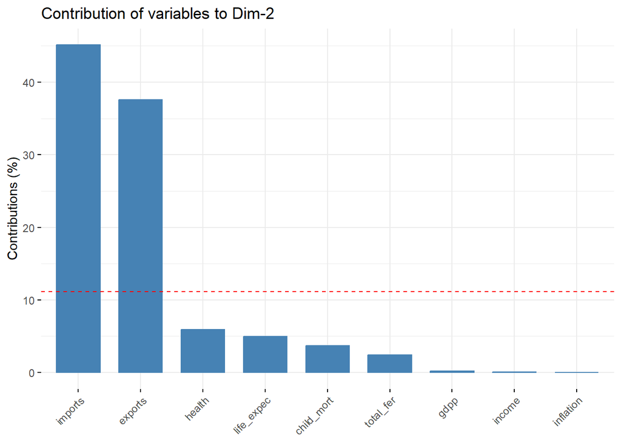

```r
fviz_contrib(pca_result, choice = "var", axes = 2)
```

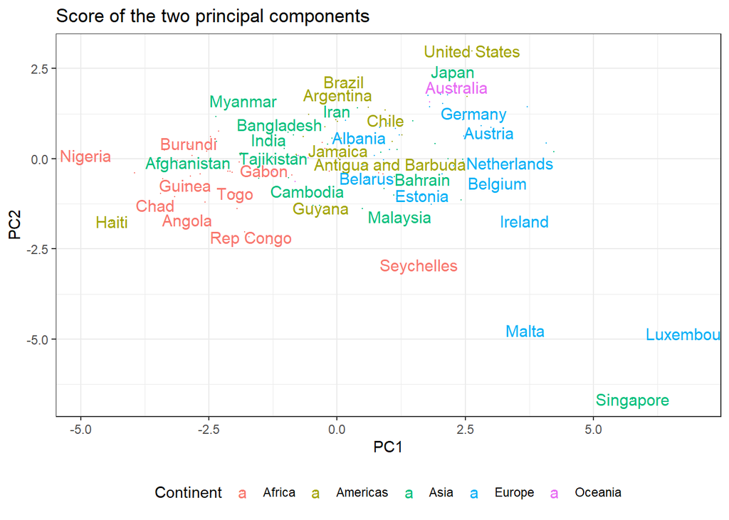

```r
data.frame(z1=pca_result$x[,1],z2=pca_result$x[,2],names,Continent) |>
  ggplot(aes(z1,z2,label=names,color=Continent)) + geom_point(size=0) +
  labs(title="Score of the two principal components ", x="PC1",y="PC2")+
  theme_bw() +
  theme(legend.position="bottom") +
  geom_text(size=4,
            hjust=0.5,
            check_overlap = TRUE)
```

**Clusters**

We remove the non-numerical columns.

```r
cluster_result <- result_tidy |>
  select(-c(country, region))
```

In order to make the cluster, we will select k = to 4

```r
k <- 4
model <- kmeans(scale(cluster_result),centers = k,nstart = 100000)
```

```r
centers <- model$centers
```

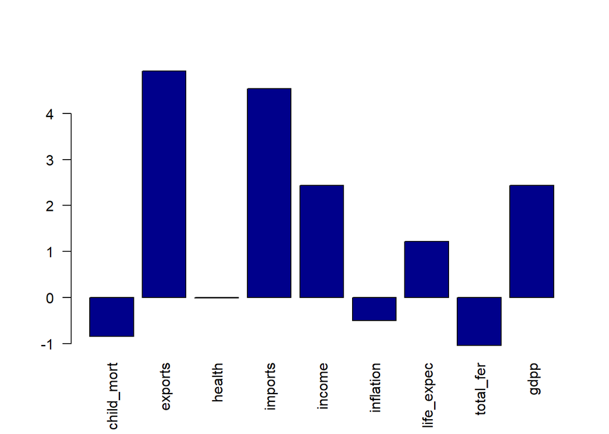

```r
barplot(centers[1,], las=2, col="darkblue")+
  theme_dark()
```

Now we do the tidy data in order to understand the clusters.

```r
means_ordered <- centers|>
  as.data.frame() |>
  mutate(cluster = row_number()) |>
  pivot_longer(-cluster,names_to = "attribute")
```

And we plot them to see the information that each clusters contains and have been taken into account.

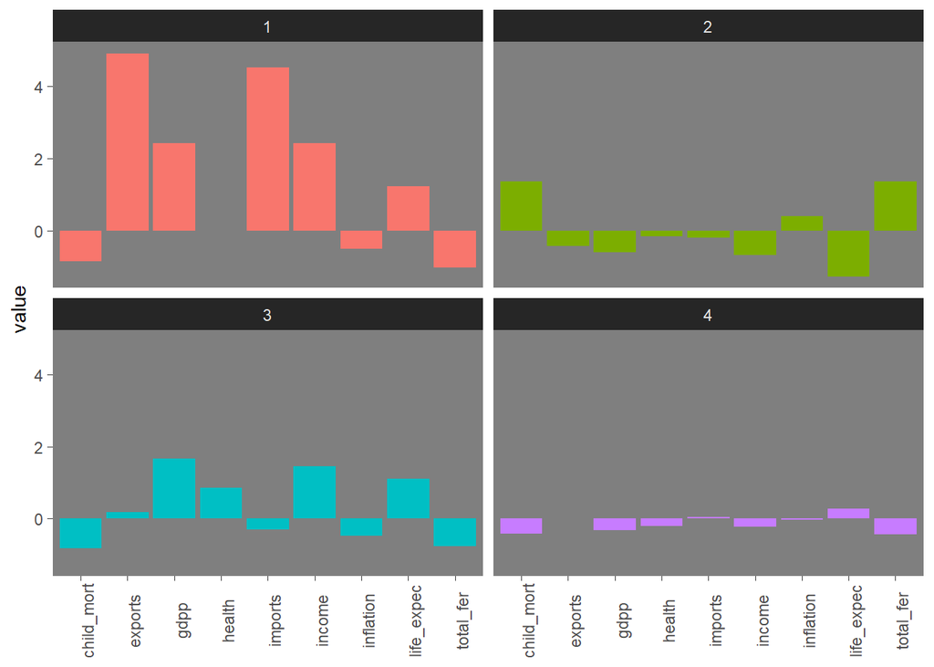

```r
means_plot <- means_ordered |>
  ggplot()+
  aes(as.factor(attribute),value, fill = as.factor(cluster))+
  geom_bar(stat = "identity")+
  #facet by cluster
  facet_wrap(~cluster)+
  theme_dark()+
  #rotate axis attributes
  theme(axis.text.x = element_text(angle = 90),
        #remove axis title to focus on the plot
        axis.title.x = element_blank(),
        panel.grid = element_blank(),
        #remove legend
        legend.position = "none")
means_plot
```

If we want to be more precise, we do silhouette and gap_stat to select the number of clusters. We will use gap_stat because the world is usually divided in 3 types of countries. Developed, under-developed and those that are in the middle.

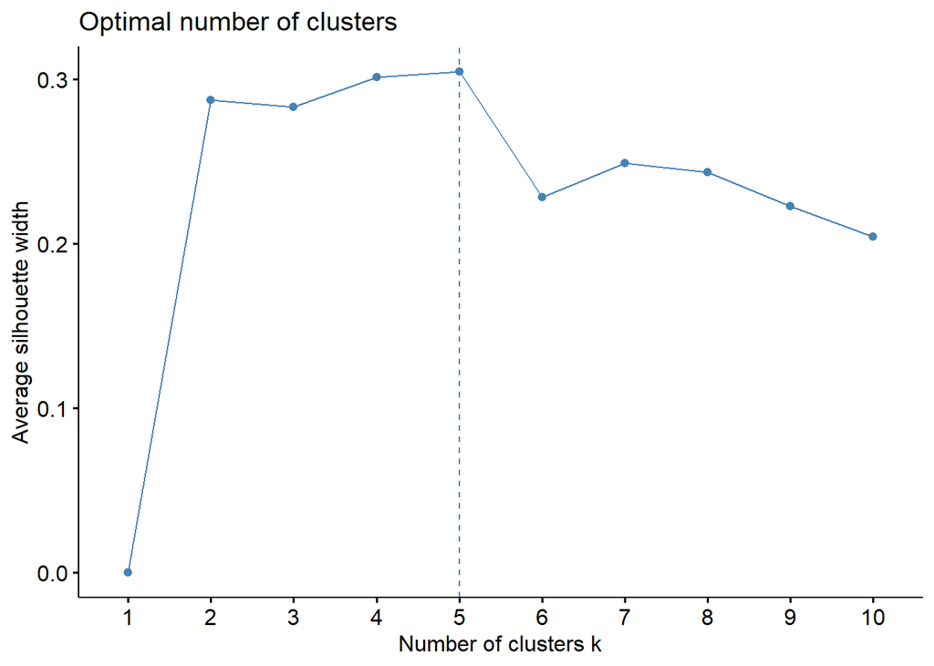

```r
fviz_nbclust(scale(cluster_result),kmeans,method = "silhouette",k.max = 10,nstart = 100)
```

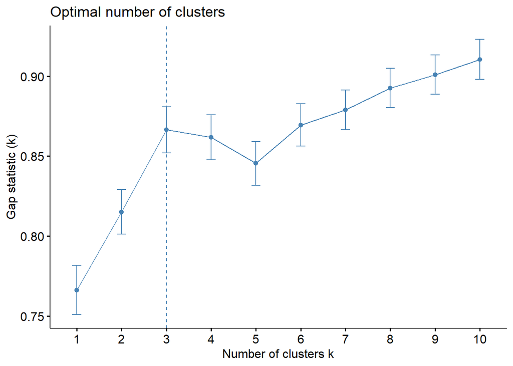

```r
fviz_nbclust(scale(cluster_result),kmeans,method = "gap_stat",k.max = 10,nstart = 100)
```

**Hierarchical clustering**

For this cluster dendrogram, we have divided it into 3 parts. Nevertheless, we cannot see clearly which are the countries within each of them. Probably blue and yellow part are those who perform better and worse.

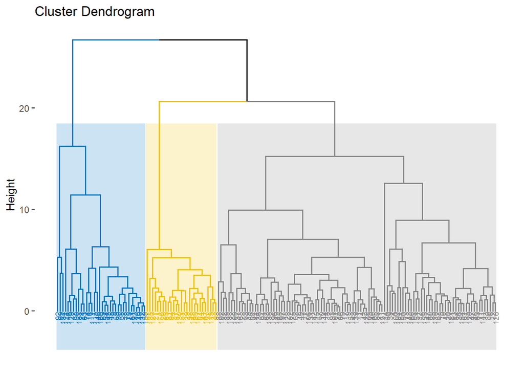

```r
d <- dist(scale(cluster_result),method = "euclidean")
hc <- hclust(d,method = "ward.D2")

fviz_dend(x = hc,
          k=3,
          palette = "jco",
          rect = TRUE, rect_fill = TRUE, cex=0.5,
          rect_border = "jco"
)
```

Finally, clustering using this plot. We can see that the red part are the developed countries that also perform well in the PCA like Luxembourg and Singapore. Those are countries with high expectancy rate, high GDP, low fertility rate but low child mortality rate as well.

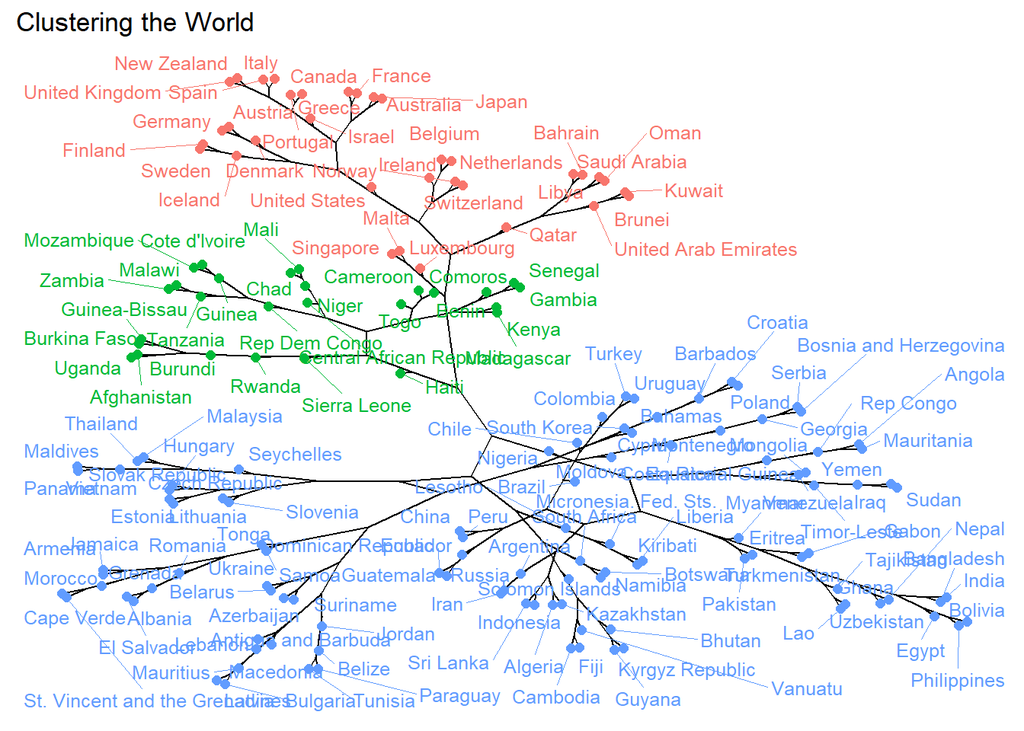

```r
hc$labels <- names
fviz_dend(x = hc,
          k = 3,
          color_labels_by_k = TRUE,
          cex = 0.8,
          type = "phylogenic",
          repel = TRUE)+  labs(title="Clustering the World") +
          theme(axis.text.x=element_blank(),axis.text.y=element_blank())
```

**Conclusions**

To sum up, we can see how the child mortality divide the world in developed world(red), underdeveloped(green), and a blue part that are an intermediate group between both. The economy(GDP, Income) and the health(child mortality, fertility rate…) are quite correlated and allow us to analyse this phenomenon.